# Лабораторная работа №2

Структуры данных в Julia

Ведьмина Александра Сергеевна

1132236003@rudn.ru

Российский университет дружбы народов

2026-09-20

## Содержание

- Цель и инструменты
- Основные структуры данных
- Операции над множествами
- Построение массивов
- Случайные векторы
- Простые числа и суммы
- Воспроизводимость
- Результаты и выводы

# Информация

## Докладчик

- Ведьмина Александра Сергеевна
- студентка
- кафедра теории вероятностей и кибербезопасности
- Российский университет дружбы народов
- 1132236003@rudn.ru

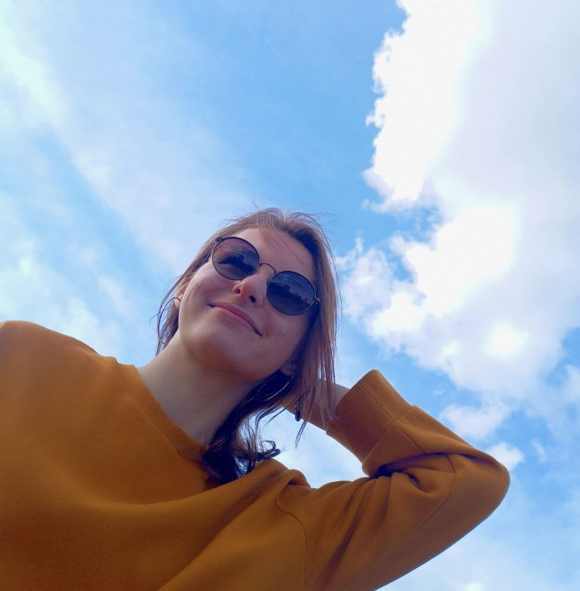

# Вводная часть

## Цель и задачи

**Цель:** изучить структуры данных Julia и применить операции над ними для решения вычислительных задач.

Задачи:

- повторить примеры для кортежей, словарей, множеств и массивов;
- выполнить задания 1–6;
- обработать случайные векторы длины 250;
- применить пакет `Primes`;
- обеспечить воспроизводимость результатов;
- проверить решения автоматическими тестами.

## Инструменты

- Julia и стандартные библиотеки `Random`, `Statistics`, `Test`;
- `Primes.jl` для вычисления простых чисел;
- Jupyter Lab и `IJulia`;
- `DrWatson` для структуры проекта;
- `Literate.jl` для производных материалов;
- Quarto для отчёта и презентации.

# Структуры данных

## Кортежи и словари

```julia
x1 = (1, 2, 3)
x2 = (1, 2.0, "tmp")
x3 = (
    a=2,
    b=1 + 2,
)

x2[1]
x3.a
"tmp" in x2
```

```julia
phonebook = Dict(
    "Иванов И.И." => (
        "867-5309",
        "333-5544",
    ),
    "Бухгалтерия" =>
        "555-2368",
)
```

- `Tuple` неизменяем и индексируется с единицы;
- `Dict` хранит пары «ключ – значение».

## Множества

Для множеств

$$A=\{0,3,4,9\},\quad
B=\{1,3,4,7\},\quad
C=\{0,1,2,4,7,8,9\}$$

вычислено объединение попарных пересечений:

```julia
P = union(
    intersect(A, B),
    intersect(A, C),
    intersect(B, C),
)
```

**Результат:** $P=\{0,1,3,4,7,9\}$.

## Результат операций над множествами

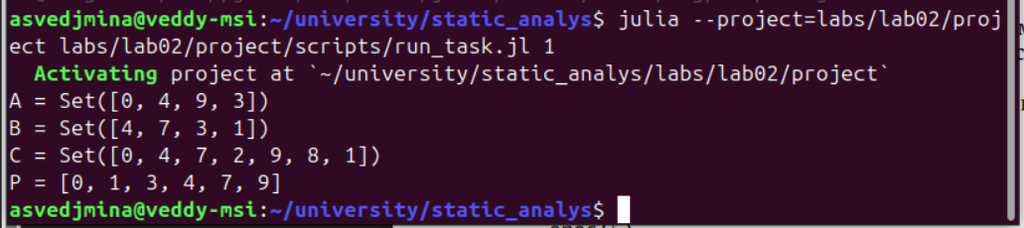

- повтор $A\cap B$ в условии не влияет на объединение;
- отдельно проверены множества элементов разных типов.

# Построение массивов

## Диапазоны

При $N=25$ построены три последовательности:

```julia
ascending = collect(1:N)

descending = collect(
    N:-1:1,
)

there_and_back = vcat(
    1:N,
    (N - 1):-1:1,
)
```

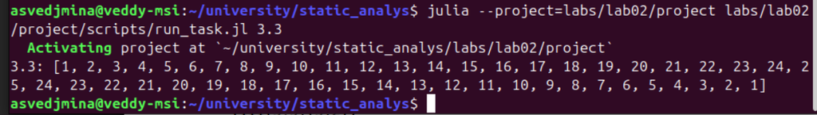

## Повторение элементов

```julia
tmp = [4, 6, 3]

first_ten = fill(
    first(tmp),
    10,
)

counts_11_10_10 = vcat(
    first(tmp),
    repeat(tmp, 10),
)
```

- `4` встречается 11 раз;
- `6` и `3` встречаются по 10 раз.

## Блочные повторения

```julia
tmp = [4, 6, 3]

blocks_10_20_30 = vcat(
    fill(tmp[1], 10),
    fill(tmp[2], 20),
    fill(tmp[3], 30),
)
```

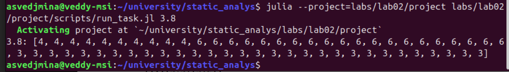

## Степени двойки

```julia
powers = vcat(
    2 .^ tmp[1:2],
    fill(
        2^tmp[3],
        4,
    ),
)

six_digits = count(
    ==('6'),
    join(powers),
)
```

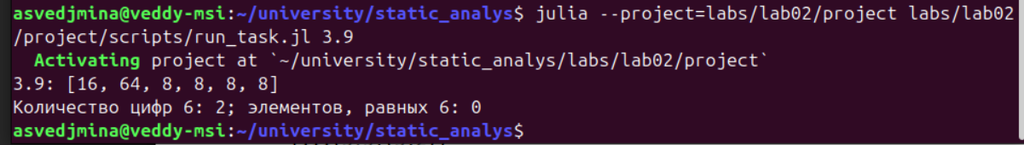

**Результат:** `[16, 64, 8, 8, 8, 8]`.

## Функциональные последовательности

В точках $x=3,3{,}1,\ldots,6$ вычислено $y=e^x\cos x$:

```julia
x_grid = collect(
    3.0:0.1:6.0,
)
y_grid = (
    exp.(x_grid) .*
    cos.(x_grid)
)
y_mean = mean(y_grid)
```

Среднее значение:

$$\overline y=53{,}1137459464.$$

# Случайные векторы

## Воспроизводимая выборка

```julia
rng = MersenneTwister(2026)
x = rand(rng, 0:999, 250)
y = rand(rng, 0:999, 250)
```

Фиксированный seed обеспечивает одинаковые выборки при каждом запуске.

Построены:

- разности $y_{i+1}-x_i$;
- линейные комбинации $x_i+2x_{i+1}-x_{i+2}$;
- отношения $\sin(y_i)/\cos(x_{i+1})$;
- корни абсолютных отклонений от среднего.

## Преобразования

```julia
differences = (
    y[2:end] .-
    x[1:end-1]
)

linear_combination = (
    x[1:end-2] .+
    2 .* x[2:end-1] .-
    x[3:end]
)

trig_ratios = (
    sin.(y[1:end-1]) ./
    cos.(x[2:end])
)
```

Согласованные срезы дают длины `249`, `248` и `249`.

## Отбор и сортировка

```julia
indices = findall(>(600), y)
y_over_600 = y[indices]
corresponding_x = x[indices]

x_sorted_by_y = x[
    sortperm(y)
]
x_top_10 = sort(
    x;
    rev=true,
)[1:10]
unique_x = unique(x)
```

- сохраняется соответствие позиций `x` и `y`;
- сортировка `x` выполняется по значениям `y`.

## Итоговая статистика

[output not shown]

Top-10:

[output not shown]

# Простые числа и суммы

## Квадраты и простые числа

```julia
squares = [
    i^2 for i in 1:100
]

myprimes = collect(
    primes(1000)
)

prime_89 = myprimes[89]
prime_slice = myprimes[
    89:99
]
```

- количество простых чисел — 168;
- 89-е простое число — 461;
- срез 89:99 — от 461 до 523.

## Вычисление сумм

| Выражение | Результат |
| --- | --- |
| $\sum_{10}^{100}(i^3+4i^2)$ | 26 852 735 |
| $\sum_{1}^{25}(2^i/i+3^i/i^2)$ | $2{,}12917\cdot10^9$ |
| Ряд произведений | 6,9763461379 |

```julia
terms = vcat(
    1.0,
    accumulate(
        *,
        [2k / (2k + 1)
         for k in 1:19],
    ),
)
```

# Воспроизводимость

## Jupyter Notebook

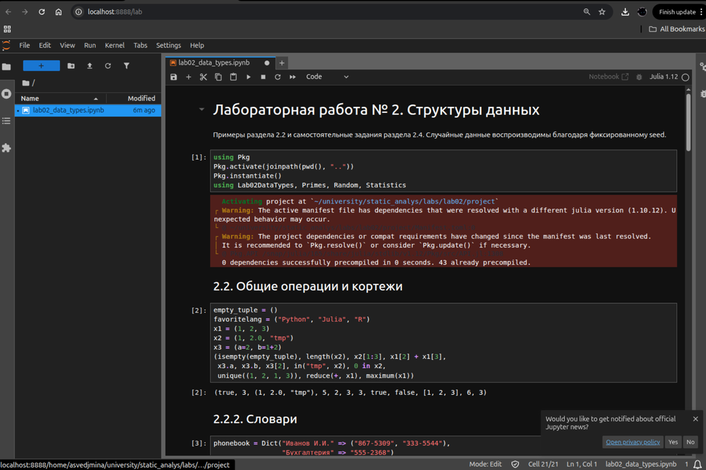

Начало notebook.

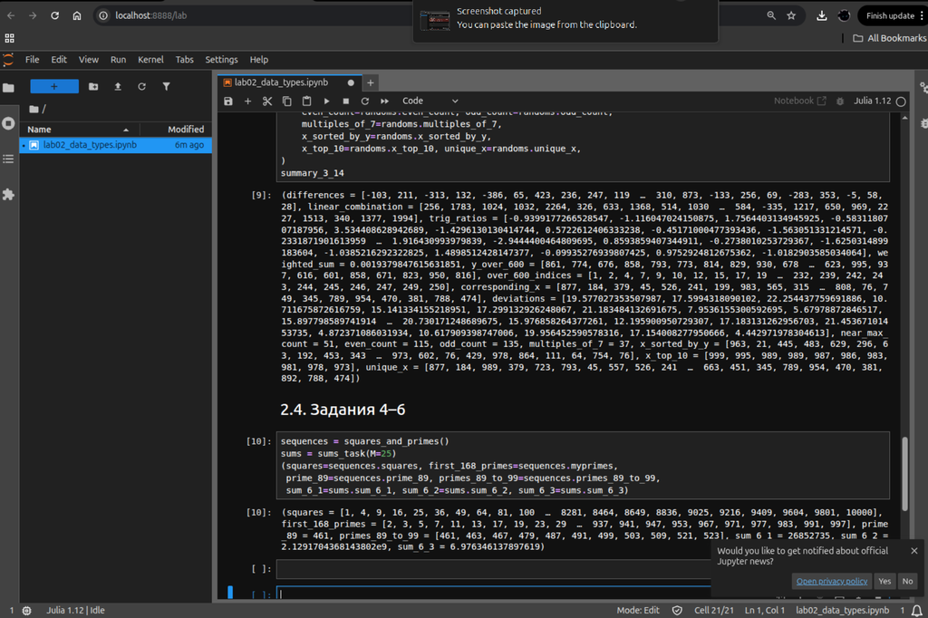

Результаты заданий.

## Производные материалы

Из единого файла `scripts/lab02_literate.jl` получены:

- `generated/lab02_code.jl`;
- выполненный `lab02_notebook.ipynb`;
- `lab02_quarto.qmd`;
- `lab02_quarto.html`.

```bash
project=labs/lab02/project
julia --project=$project \
  $project/scripts/generate_outputs.jl
```

## Автоматические тесты

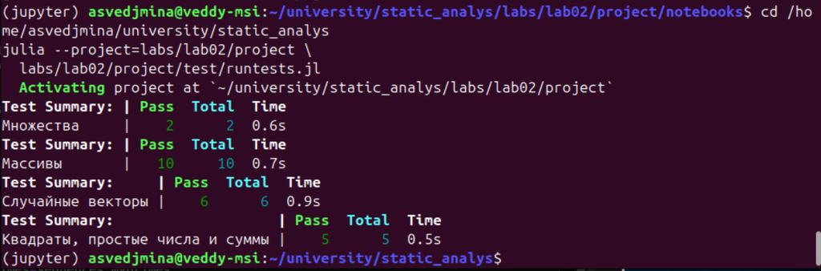

Проверены:

# Заключение

## Результаты

- выполнены все примеры и самостоятельные задания;
- освоены кортежи, словари, множества и массивы;
- применены срезы, broadcasting, фильтрация и сортировка;
- обработаны воспроизводимые случайные выборки;
- найдены простые числа и вычислены три суммы;
- создан воспроизводимый literate-конвейер;
- все автоматические тесты пройдены.

## Вывод

Цель работы достигнута.

Структуры данных Julia позволяют компактно выражать операции над коллекциями, а broadcasting и индексирование дают возможность выполнять векторные вычисления без явных циклов.

Фиксированное окружение, seed генератора и единый literate-источник делают полученные результаты полностью воспроизводимыми.